# Quality of Red Wine

# Bivariate Analysis

### Talk about some of the relationships you observed in this part of the investigation. How did the feature(s) of interest vary with other features in the dataset?

The data sets contain several correlating variables, but the correlations are usually not that big (>0.7). Quality clearly varied with especially alcohol, volatile acidity and sulphates.

Quality and alcohol correlate somewhat linearly, and it’s worth noting that the difference is especially big on the higher qualities.

We see the same trend for sulphates, and as with alcohol the trend is clearer in the higher range. The samples with quality 3 seem to be somewhat of an outlier: many times they aren’t really following the trend. This could be because there are just a few samples of quality 3, or because of some other trait that is special for quality 3 wines.

### Did you observe any interesting relationships between the other features (not the main feature(s) of interest)?

I expected some features to correlate because of their chemical nature. For example the total ammount of sulfuric oxide contains all the free oxide, and so naturally they would correlate.

Fixed acidity seemed to decrease with volatile acidity as well.

Sugar was shown to correlate quite strongly with density for the lower 90% of sugar levels. Removing the top 10% sugar also increased correlations between quality and both sugar and density.

### What was the strongest relationship you found?

The strongest relationship was citric and fixed acidity, with a correlation of almost 0.7. In terms of quality, the strongest relationship was seen with alcohol, and especially for the higher quality wines the trend was evident.

# Multivariate Plots Section

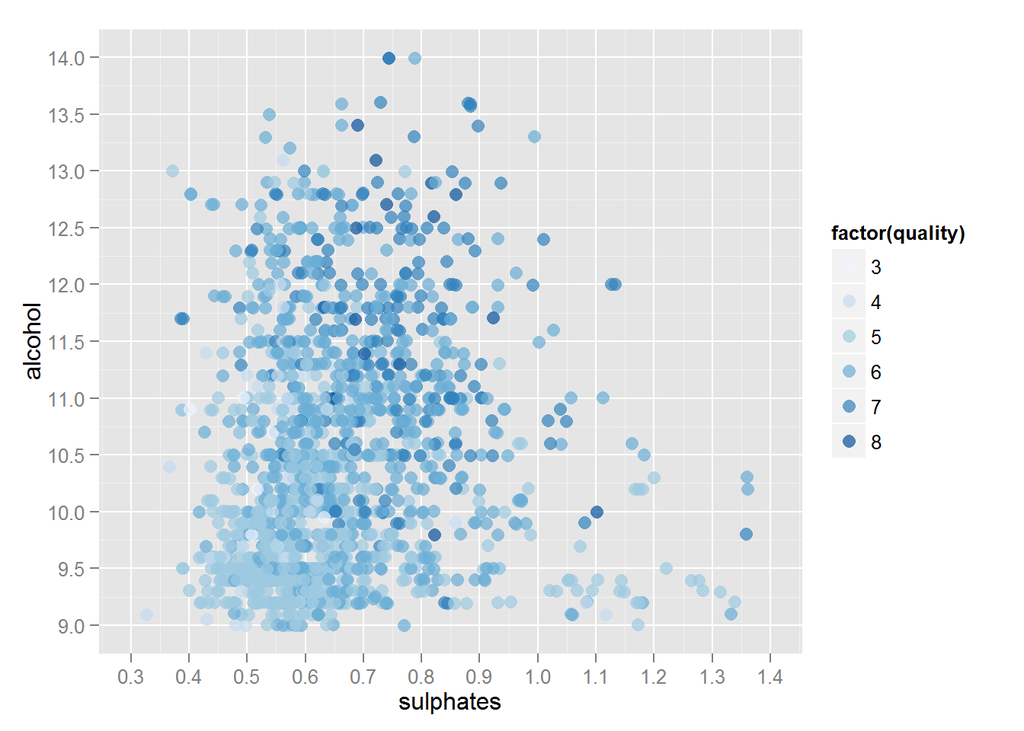

This plot shows us that in general, the high quality wines have both high sulphate and alcohol, which we knew from before. We also see that there’s a tendency for the alcohol level to deviate relatively more than the sulphate when it comes to varying with quality.

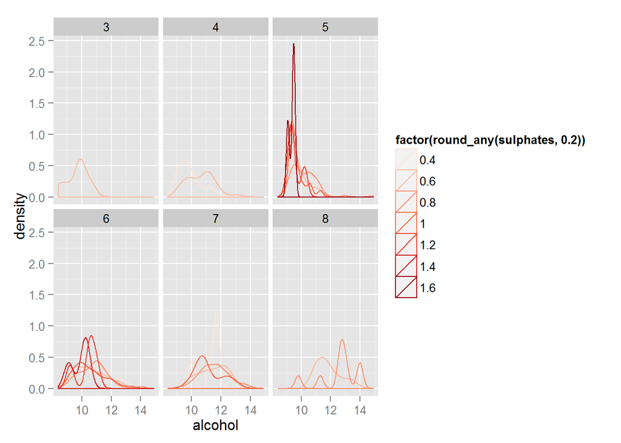

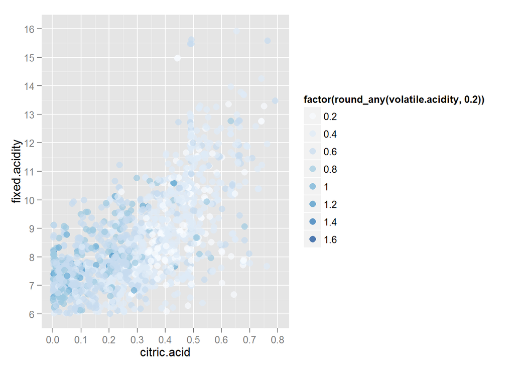

This plot shows the three acidity measurements.

Let’s try a linear model with the most important chemical components to predict quality:

```
##
## Calls:
## m1: lm(formula = quality ~ alcohol, data = rw)
## m2: lm(formula = quality ~ alcohol + volatile.acidity, data = rw)
## m3: lm(formula = quality ~ alcohol + volatile.acidity + sulphates,
##     data = rw)
## m4: lm(formula = quality ~ alcohol + volatile.acidity + sulphates +
##     pH, data = rw)
##
## =========================================================
##                      m1        m2        m3        m4
## ---------------------------------------------------------
## (Intercept)        1.875***  3.095***  2.611***  3.493***
##                   (0.175)   (0.184)   (0.196)   (0.385)
## alcohol            0.361***  0.314***  0.309***  0.321***
##                   (0.017)   (0.016)   (0.016)   (0.016)
## volatile.acidity            -1.384*** -1.221*** -1.156***
##                             (0.095)   (0.097)   (0.100)
## sulphates                              0.679***  0.635***
##                                       (0.101)   (0.102)
## pH                                              -0.306**
##                                                 (0.115)
## ---------------------------------------------------------
## R-squared             0.227     0.317     0.336     0.339
## adj. R-squared        0.226     0.316     0.335     0.337
## sigma                 0.710     0.668     0.659     0.657
## F                   468.267   370.379   268.912   204.210
## p                     0.000     0.000     0.000     0.000
## Log-likelihood    -1721.057 -1621.814 -1599.384 -1595.858
## Deviance            805.870   711.796   692.105   689.059
## AIC                3448.114  3251.628  3208.768  3203.717
## BIC                3464.245  3273.136  3235.654  3235.980
## N                  1599      1599      1599      1599
## =========================================================
```

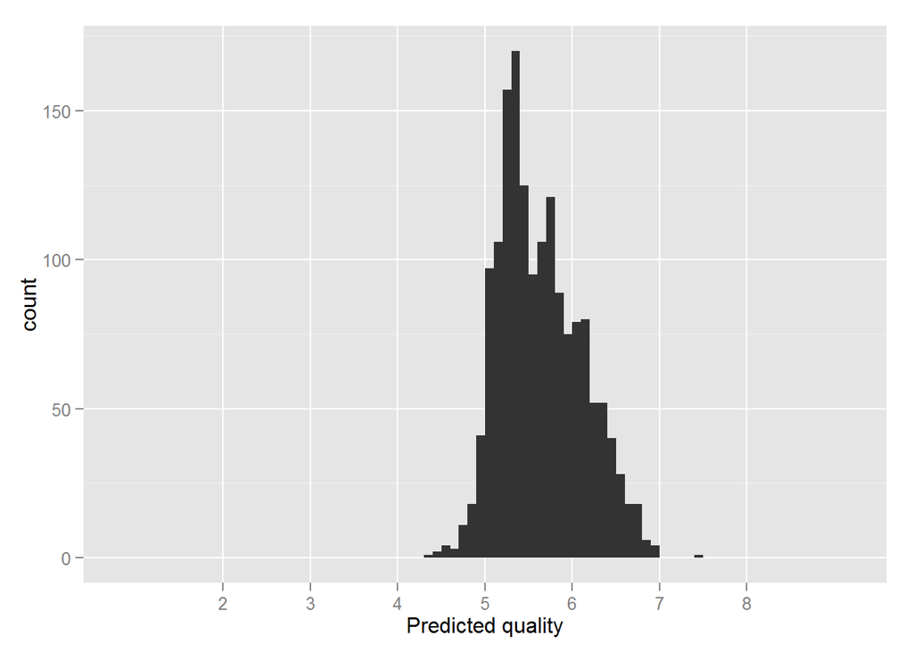

This histogram shows what quality our linear model predicted for the original wines. We see that our model mostly places wines in the 4.5 to 7 range, which is not surprising given the distribution of the qualities. Even though our quality is given as a discrete and not continuous variable, the linear regression model gives us a hint of how a wine will score. Let’s do a rounding, and have a look at how often we’re missing and how much.

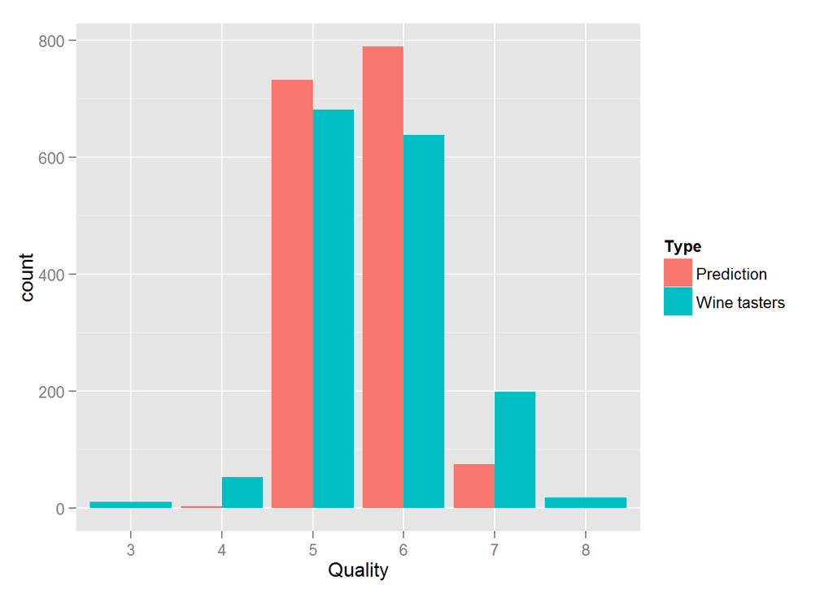

This histogram compares the predicted quality (when the predictions are rounded to the nearest integer), compared to the actual quality given by the wine tasters.

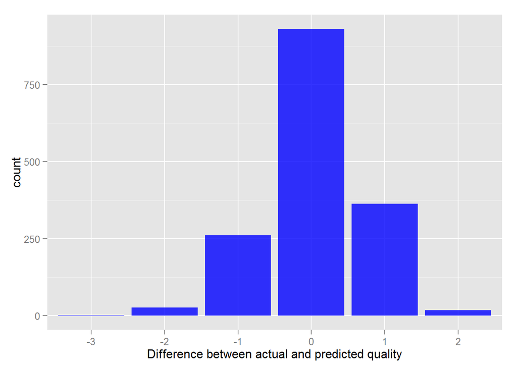

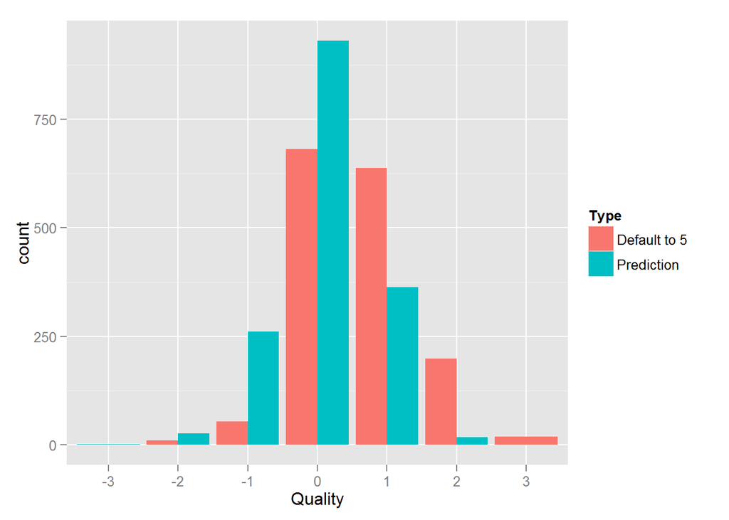

The blue color indicates the count of wines that were assigned the correct quality by the rounded linear prediction. The red color indicates the count of wines that were assigned the correct quality by the naive prediction that all wines are quality 5. It’s clear that the linear predictor has more correct predictions, but the difference here isn’t huge.

# Multivariate Analysis

### Were there any interesting or surprising interactions between features?

Citric acid and fixed acidity had some relationship between them. Grouping by volatile acidity didn’t show any easily recognizable pattern, but you could also tell they weren’t purely random either.

### OPTIONAL: Did you create any models with your dataset? Discuss the strengths and limitations of your model.

# Final Plots and Summary

### Plot One

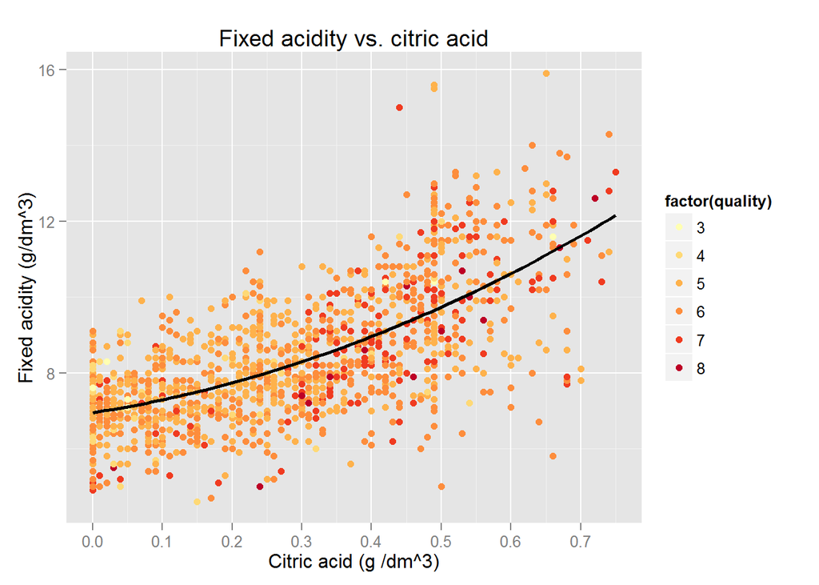

### Plot Two

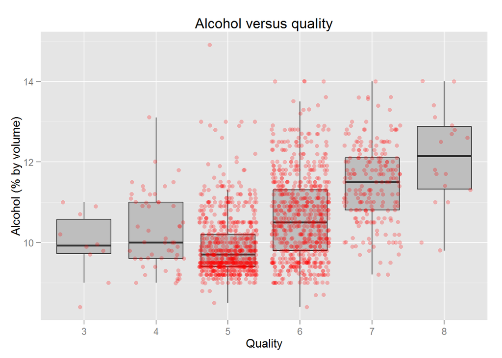

### Description Two

All low quality wines have low alcohol levels. All high quality wines have high alcohol levels, increasing from quality five thru 8. The lowest average is found for quality 5 wines, at 9.9%. For quality 8 the average is 12.1. Perhaps the clearest sign of something goin on is the fact that 75% of all quality 8 wines have a higher alcohol percentage than all of the quality 3 wines. As mentioned earlier, this could be due to the age of the wines, which has not been given. Storing wine for a long time tends to increase alcohol. Another possibility is that good wines just tend to have a higher alcohol, or that wine tasters like the taste.

### Plot Three

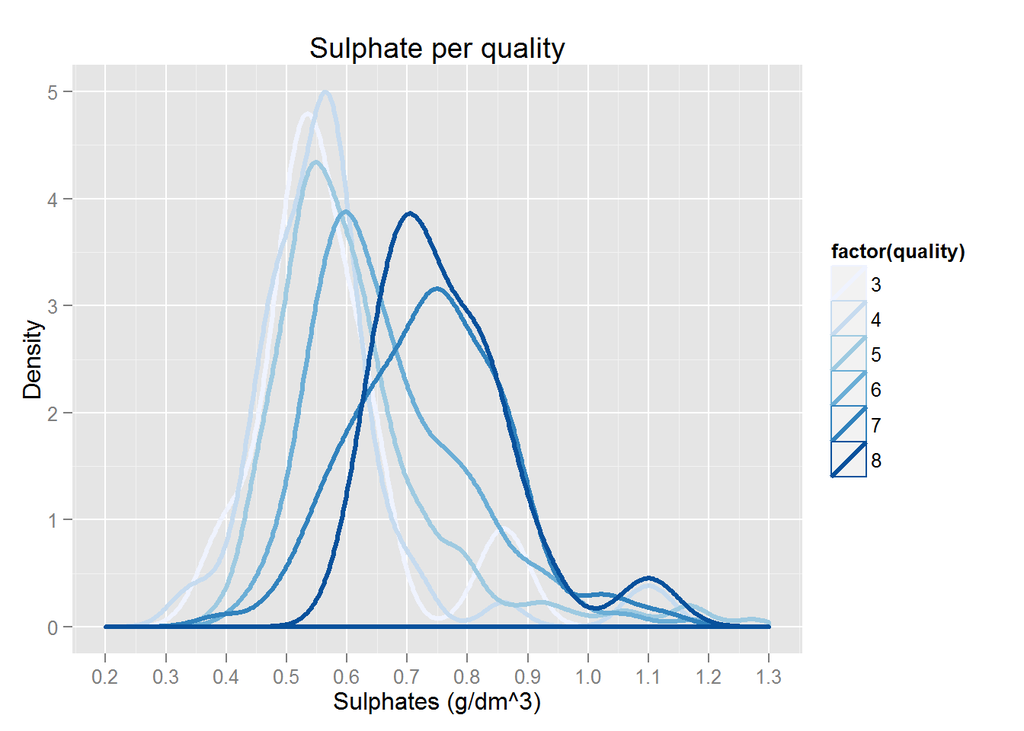

### Description Three

This plot shows how the densities of the sulphate curves for each of the different qualities look. Higher quality wines have more sulphate, but also somewhat flatter curves. The mean difference is relatively big, with quality 7 wines at 0.74 $g/dm^3$ having 29% than quality 3 wnies at 0.57 $g/dm^3$. Sulphates typically go along with strong smells, and so perhaps this correlation is seen because wines rich on sulphate may have a stronger and more complex aroma.

# Reflection

The data set contains 1600 wines, and while this is a lot of wines, it’s not that many at the same time. For example there are only around 10 wines with quality 3, and no wines with quality 0,1,2, 9 or 10. There’s also quite a bit of relevant information we don’t have, we don’t know the age of the wines for example. Aging wine will typically let water vaporize, and in turn thus increase a lot of chemical concentrations. Are the best wines in general older? We can’t tell. I’m pretty sure age would be a valuable data addition, but also acknowledge that lookin only at chemical values was the point of the data set. I wasn’t expecting to find very high correlations between quality and chemicals, because a lot of the experience of drinking a good red wine is attributed to the different specific aromas. However there’s clearly some correlation, as seen with alcohol, pH, sulphates and so on.